# Dog Breeds

2022-02-022

# TidyTuesday

Join the R4DS Online Learning Community in the weekly #TidyTuesday event! Every week we post a raw dataset, a chart or article related to that dataset, and ask you to explore the data. While the dataset will be “tamed”, it will not always be tidy! As such you might need to apply various R for Data Science techniques to wrangle the data into a true tidy format. The goal of TidyTuesday is to apply your R skills, get feedback, explore other’s work, and connect with the greater #RStats community! As such we encourage everyone of all skills to participate!

# Load the weekly Data

Data is from the Dog Breeds dataset found on the R For Data Science/TidyTuesday github

> Thomas Mock (2022). Tidy Tuesday: A weekly data project aimed at the R ecosystem. https://github.com/rfordatascience/tidytuesday.

## Readme

### The idea behind this analysis is to, based on the ratings, find what is mathematically the best dog breed.

*In the end what kind of dog breed is best for you is all about preferences, this is just meant to act as a “guide” based on the ratings I found*

```
## # A tibble: 16 x 4
##    Trait                      Trait_1                    Trait_5  Description
##    <chr>                      <chr>                      <chr>    <chr>
##  1 Affectionate With Family   Independent                Lovey-D~ How affection~
##  2 Good With Young Children   Not Recommended            Good Wi~ A breed's lev~
##  3 Good With Other Dogs       Not Recommended            Good Wi~ How generally~
##  4 Shedding Level             No Shedding                Hair Ev~ How much fur ~
##  5 Coat Grooming Frequency    Monthly                    Daily    How frequentl~
##  6 Drooling Level             Less Likely to Drool       Always ~ How drool-pro~
##  7 Coat Type                  -                          -        Canine coats ~
##  8 Coat Length                -                          -        How long the ~
##  9 Openness To Strangers      Reserved                   Everyon~ How welcoming~
## 10 Playfulness Level          Only When You Want To Play Non-Stop How enthusias~
## 11 Watchdog/Protective Nature What's Mine Is Yours       Vigilant A breed's ten~
## 12 Adaptability Level         Lives For Routine          Highly ~ How easily a ~
## 13 Trainability Level         Self-Willed                Eager t~ How easy it w~
## 14 Energy Level               Couch Potato               High En~ The amount of~
## 15 Barking Level              Only To Alert              Very Vo~ How often thi~
## 16 Mental Stimulation Needs   Happy to Lounge            Needs a~ How much ment~
```

The Ideal dog breed should have high ratings in the “positive” categories.

Some are subjective depending on a person’s lifestyle and preference but the ones I will rate on will be

- Affectionate With Family
- Good With Young Children
- Good With Other Dogs
- Openness To Strangers
- Watchdog/Protective Nature
- Trainability Level

I will list these traits with a negative value (i.e. these values will be subtracted from overall score)

- Coat Grooming Frequency
- Drooling Level
- Shedding Level
- Barking Level

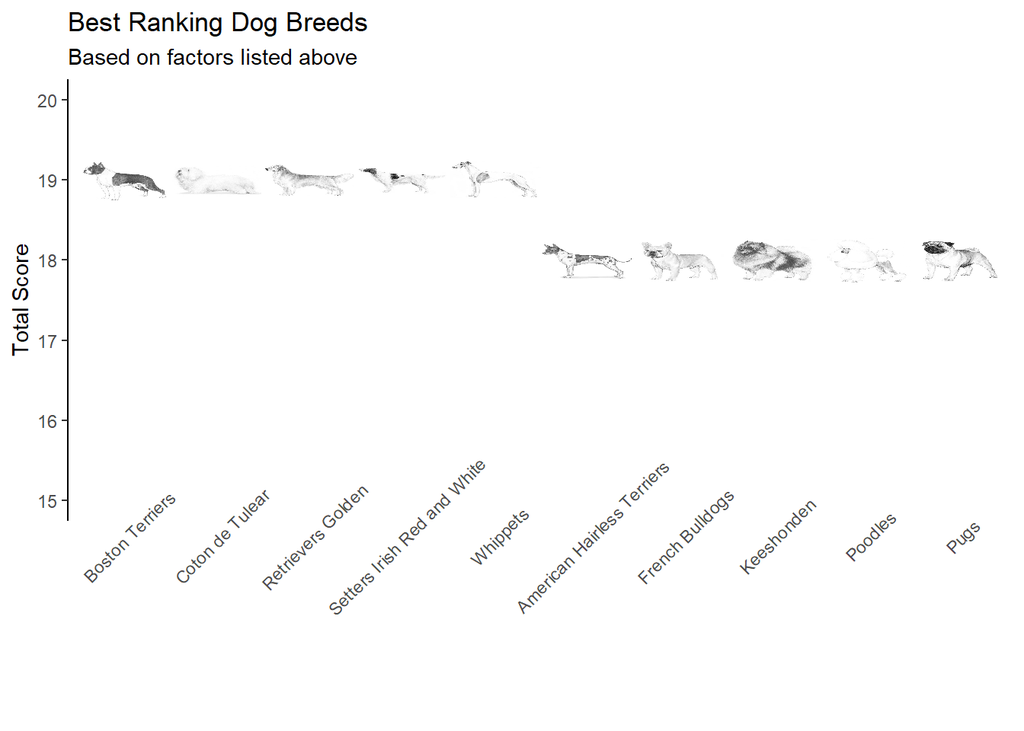